# Data Exploration

Julia

2025-08-12

## Brief comment

This markdown document was created to briefly show the outputs of the code included in the `data_exploration.R` as the full data will not be uploaded for confidentiality reasons. Therefore, this file will have the exact same code with small modifications to show that each step is doing.

### 1. Loading packages and baseline data sets

```r
# Loading packages

library(dplyr)
library(tidyverse)
library(openxlsx)
library(gridExtra)
library(vegan)
```

```r
library(tidyr)
library(ggplot2)
library(ggstatsplot)
# Loading baseline data sets

alladults <- read.csv("C:/Users/julia/OneDrive - University of Edinburgh/EEB_MSc_UEd/Dissertation/diss/data/AdultsII.csv")  # loading complete adult blue tits data
allbirdphen <- read.csv("C:/Users/julia/OneDrive - University of Edinburgh/EEB_MSc_UEd/Dissertation/diss/data/Bird_PhenologyII.csv")  # loading complete phenology data
nestlings <- read.csv("C:/Users/julia/OneDrive - University of Edinburgh/EEB_MSc_UEd/Dissertation/diss/data/NestlingsII.csv")
blutidf <- read.csv("C:/Users/julia/OneDrive - University of Edinburgh/EEB_MSc_UEd/Dissertation/diss/data/blutidf_2025.csv")
blutidf_3yo <- read.csv("C:/Users/julia/OneDrive - University of Edinburgh/EEB_MSc_UEd/Dissertation/diss/data/blutidf_3yo_2025.csv")
fed_df <- read.csv("C:/Users/julia/OneDrive - University of Edinburgh/EEB_MSc_UEd/Dissertation/diss/data/fed_df_2025.csv")  # loading first egg lay date data
cs_df <- read.csv("C:/Users/julia/OneDrive - University of Edinburgh/EEB_MSc_UEd/Dissertation/diss/data/cs_df_2025.csv")  # loading clutch size data
suc_df <- read.csv("C:/Users/julia/OneDrive - University of Edinburgh/EEB_MSc_UEd/Dissertation/diss/data/suc_df_2025.csv")  # loading number of fledgelings data
sites <- read.csv("C:/Users/julia/OneDrive - University of Edinburgh/EEB_MSc_UEd/Dissertation/diss/data/site_detailsII.csv")  # loading site-specific data
habitat <- read.csv("C:/Users/julia/OneDrive - University of Edinburgh/EEB_MSc_UEd/Dissertation/diss/data/Habitats.csv")  # loading data used to calculate foliage score
habitat_foliage_scores <- read.csv("C:/Users/julia/OneDrive - University of Edinburgh/EEB_MSc_UEd/Dissertation/diss/data/Habitat_SiteII.csv") # loading data on foliage score
environment <- read.csv("C:/Users/julia/OneDrive - University of Edinburgh/EEB_MSc_UEd/Dissertation/diss/data/environment_2025.csv")  # loading environmental predictors
caterpillars <- read.csv("C:/Users/julia/OneDrive - University of Edinburgh/EEB_MSc_UEd/Dissertation/diss/data/Lepidoptera_Abundance.csv")  # loading caterpillar data
```

### 2. Raw data and mean+se values for each breeding trait without capping observations based on age

```r
summarySE <- function(data=NULL, measurevar, groupvars=NULL, na.rm=FALSE,
                      conf.interval=.95, .drop=TRUE) {
  library(plyr)
  length2 <- function (x, na.rm=FALSE) {
    if (na.rm) sum(!is.na(x))
    else       length(x)
  }

  datac <- ddply(data, groupvars, .drop=.drop,
                 .fun = function(xx, col) {
                   c(N    = length2(xx[[col]], na.rm=na.rm),
                     mean = mean   (xx[[col]], na.rm=na.rm),
                     sd   = sd     (xx[[col]], na.rm=na.rm)
                   )
                 },
                 measurevar
  )

  datac <- plyr::rename(datac, c("mean" = measurevar))
  datac$se <- datac$sd / sqrt(datac$N)
  ciMult <- qt(conf.interval/2 + .5, datac$N-1)
  datac$ci <- datac$se * ciMult

  return(datac)
}
```

#### a) By age class:

```r
## AGE ##

# First egg lay date

nrow(fed_df)
```

```
## [1] 1302
```

```r
length(unique(fed_df$ring))
```

```
## [1] 1006
```

```r
fed_summary <- summarySE(fed_df, measurevar='fed', groupvars='yo')
```

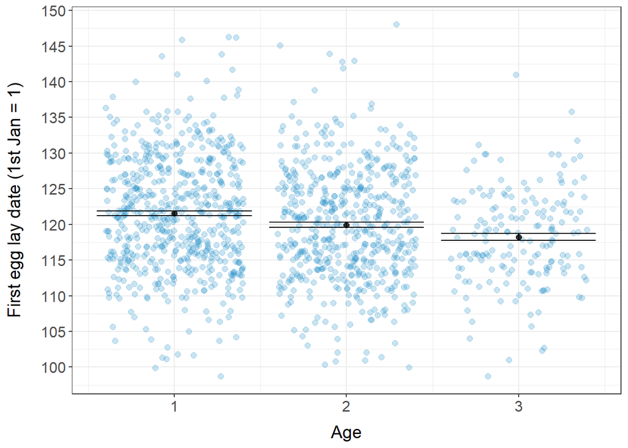

```r
ggplot() +
  geom_jitter(data=fed_df, aes(x=yo, y=fed), size=2, alpha=0.25, colour = "#248fc9") +
  geom_errorbar(data=fed_summary, aes(x=yo, y=fed, ymin=fed-se, ymax=fed+se)) +
  geom_point(data=fed_summary, aes(x=yo, y=fed), colour = "black", size = 2, alpha = 0.8) +
  labs(x = "Age", y = "First egg lay date (1st Jan = 1)") +
  theme_bw() +
  scale_y_continuous(breaks=seq(90,200,5)) +
  scale_x_continuous(breaks=seq(1,7,1)) +
  theme(axis.title = element_text(size = 14),
        axis.text = element_text(size = 12),
        axis.title.x = element_text(margin = unit(c(3, 0, 0, 0), "mm")),
        axis.title.y = element_text(margin = unit(c(0, 5, 0, 0), "mm")))
```

```r
# Clutch size

nrow(cs_df)
```

```
## [1] 1600
```

```r
length(unique(cs_df$ring))
```

```
## [1] 1188
```

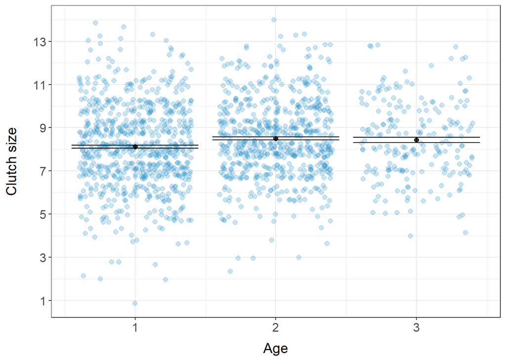

```r
cs_summary <- summarySE(cs_df, measurevar='cs', groupvars='yo')

ggplot() +
  geom_jitter(data=cs_df, aes(x=yo, y=cs), size=2, alpha=0.25, colour = "#248fc9") +
  geom_errorbar(data=cs_summary, aes(x=yo, y=cs, ymin=cs-se, ymax=cs+se)) +
  geom_point(data=cs_summary, aes(x=yo, y=cs), colour = "black", size = 2, alpha = 0.8) +
  labs(x = "Age", y = "Clutch size") +
  theme_bw() +
  scale_y_continuous(breaks=seq(1,15,2)) +
  scale_x_continuous(breaks=seq(1,7,1)) +
  theme(axis.title = element_text(size = 14),
        axis.text = element_text(size = 12),
        axis.title.x = element_text(margin = unit(c(3, 0, 0, 0), "mm")),
        axis.title.y = element_text(margin = unit(c(0, 5, 0, 0), "mm")))
```

```r
# Fledgeling success

nrow(suc_df)
```

```
## [1] 1413
```

```r
length(unique(suc_df$ring))
```

```
## [1] 1079
```

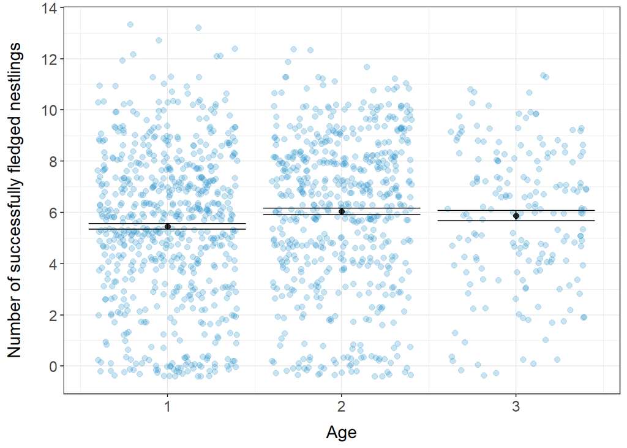

```r
suc_summary <- summarySE(suc_df, measurevar='suc', groupvars='yo')

ggplot() +
  geom_jitter(data=suc_df, aes(x=yo, y=suc), size=2, alpha=0.25, colour = "#248fc9") +
  geom_errorbar(data=suc_summary, aes(x=yo, y=suc, ymin=suc-se, ymax=suc+se)) +
  geom_point(data=suc_summary, aes(x=yo, y=suc), colour = "black", size = 2, alpha = 0.8) +
  labs(x = "Age", y = "Number of successfully fledged nestlings") +
  theme_bw() +
  scale_y_continuous(breaks=seq(0,15,2)) +
  scale_x_continuous(breaks=seq(1,7,1)) +
  theme(axis.title = element_text(size = 14),
        axis.text = element_text(size = 12),
        axis.title.x = element_text(margin = unit(c(3, 0, 0, 0), "mm")),
        axis.title.y = element_text(margin = unit(c(0, 5, 0, 0), "mm")))
```

#### b) By age at last reproduction class:

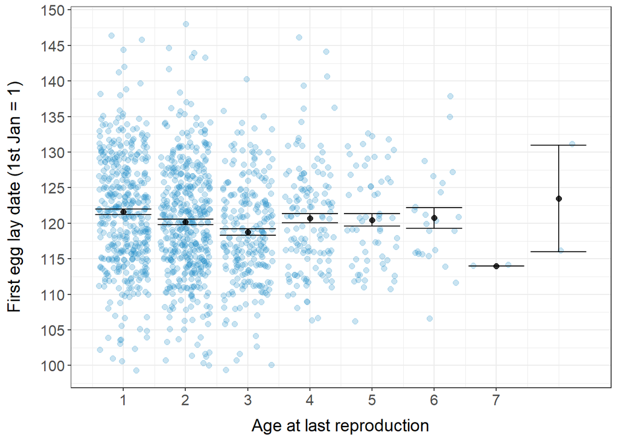

```r
# First egg lay date

fed_summary <- summarySE(fed_df, measurevar='fed', groupvars='w')

ggplot() +
  geom_jitter(data=fed_df, aes(x=w, y=fed), size=2, alpha=0.25, colour = "#248fc9") +
  geom_errorbar(data=fed_summary, aes(x=w, y=fed, ymin=fed-se, ymax=fed+se)) +
  geom_point(data=fed_summary, aes(x=w, y=fed), colour = "black", size = 2, alpha = 0.8) +
  labs(x = "Age at last reproduction", y = "First egg lay date (1st Jan = 1)") +
  theme_bw() +
  scale_y_continuous(breaks=seq(90,200,5)) +
  scale_x_continuous(breaks=seq(1,7,1)) +
  theme(axis.title = element_text(size = 14),
        axis.text = element_text(size = 12),
        axis.title.x = element_text(margin = unit(c(3, 0, 0, 0), "mm")),
        axis.title.y = element_text(margin = unit(c(0, 5, 0, 0), "mm")))
```

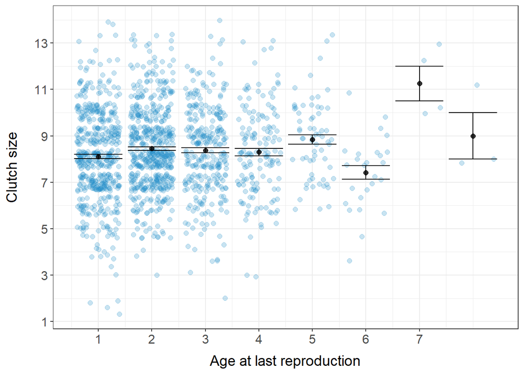

```r
# Clutch size

cs_summary <- summarySE(cs_df, measurevar='cs', groupvars='w')

ggplot() +
  geom_jitter(data=cs_df, aes(x=w, y=cs), size=2, alpha=0.25, colour = "#248fc9") +
  geom_errorbar(data=cs_summary, aes(x=w, y=cs, ymin=cs-se, ymax=cs+se)) +
  geom_point(data=cs_summary, aes(x=w, y=cs), colour = "black", size = 2, alpha = 0.8) +
  labs(x = "Age at last reproduction", y = "Clutch size") +
  theme_bw() +
  scale_y_continuous(breaks=seq(1,15,2)) +
  scale_x_continuous(breaks=seq(1,7,1)) +
  theme(axis.title = element_text(size = 14),
        axis.text = element_text(size = 12),
        axis.title.x = element_text(margin = unit(c(3, 0, 0, 0), "mm")),
        axis.title.y = element_text(margin = unit(c(0, 5, 0, 0), "mm")))
```

```r
# Fledgeling success

suc_summary <- summarySE(suc_df, measurevar='suc', groupvars='w')
```

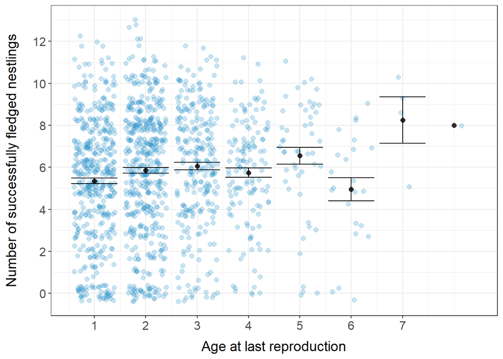

```r
ggplot() +
  geom_jitter(data=suc_df, aes(x=w, y=suc), size=2, alpha=0.25, colour = "#248fc9") +
  geom_errorbar(data=suc_summary, aes(x=w, y=suc, ymin=suc-se, ymax=suc+se)) +
  geom_point(data=suc_summary, aes(x=w, y=suc), colour = "black", size = 2, alpha = 0.8) +
  labs(x = "Age at last reproduction", y = "Number of successfully fledged nestlings") +
  theme_bw() +
  scale_y_continuous(breaks=seq(0,15,2)) +
  scale_x_continuous(breaks=seq(1,7,1)) +
  theme(axis.title = element_text(size = 14),
        axis.text = element_text(size = 12),
        axis.title.x = element_text(margin = unit(c(3, 0, 0, 0), "mm")),
        axis.title.y = element_text(margin = unit(c(0, 5, 0, 0), "mm")))
```

### 3. Sample sizes of each breeding trait by age

```r
# 1. First egg lay date

fed_age <- fed_df %>% dplyr::count(yo)

fed_w <- fed_df %>% dplyr::count(w)

fed_age  # here we can see the number of observations per age group
```

```
##   yo   n
## 1  1 598
## 2  2 531
## 3  3 173
```

```r
fed_w  # and here we can see the number of observations per age-at-last-reproduction group
```

```
##   w   n
## 1 1 410
## 2 2 436
## 3 3 238
## 4 4 132
## 5 5  58
## 6 6  24
## 7 7   2
## 8 8   2
```

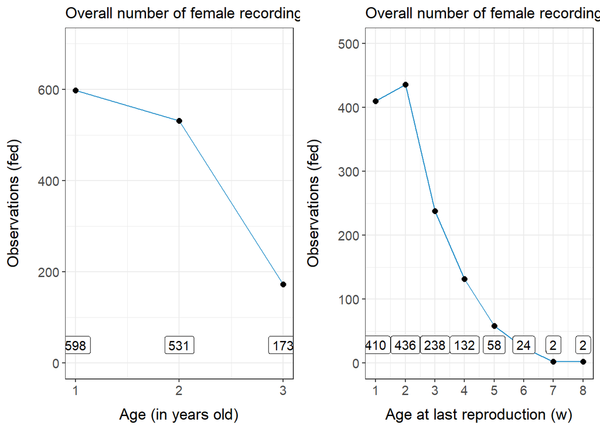

```r
fedplot1 <- ggplot(fed_df, aes(x=yo)) +
  geom_freqpoly(colour="#248fc9", binwidth=1, linejoin = "round") +
  geom_point(stat="bin", aes(y=after_stat(count)), binwidth=1, colour="black", size = 2) +
  geom_label(stat="count", label = fed_age$n, vjust=-0.5, data = fed_age) +
  theme_bw() +
  scale_x_continuous(breaks=seq(1,3,1), limits=c(1,3)) +
  scale_y_continuous(limits=c(0,700)) +
  labs(x = "Age (in years old)", y = "Observations (fed)", title = "Overall number of female recordings per age (yo) group") +
  theme( axis.title = element_text(size = 13),
         axis.text = element_text(size = 11),
         axis.title.x = element_text(margin = unit(c(3, 0, 0, 0), "mm")),
         axis.title.y = element_text(margin = unit(c(0, 5, 0, 0), "mm")))

fedplot2 <- ggplot(fed_df, aes(x=w)) +
  geom_freqpoly(colour="#248fc9", binwidth=1, linejoin = "round") +
  geom_point(stat="bin", aes(y=after_stat(count)), binwidth=1, colour="black", size = 2) +
  geom_label(stat="count", label = fed_w$n, vjust=-0.5, data = fed_w) +
  theme_bw() +
  scale_x_continuous(breaks=seq(1,8,1), limits=c(1,8)) +
  scale_y_continuous(limits=c(0,500)) +
  labs(x = "Age at last reproduction (w)", y = "Observations (fed)", title = "Overall number of female recordings per age-at-last-reproduction (w) group") +
  theme( axis.title = element_text(size = 13),
         axis.text = element_text(size = 11),
         axis.title.x = element_text(margin = unit(c(3, 0, 0, 0), "mm")),
         axis.title.y = element_text(margin = unit(c(0, 5, 0, 0), "mm")))

grid.arrange(fedplot1, fedplot2, ncol=2, nrow = 1)
```

```r
## For clutch size

cs_age <- cs_df %>% dplyr::count(yo)

cs_w <- cs_df %>% dplyr::count(w)

cs_age  # number of observations per age group
```

```
##   yo   n
## 1  1 740
## 2  2 648
## 3  3 212
```

```r
cs_w  # number of observations per age-at-last-reproduction group
```

```
##   w   n
## 1 1 508
## 2 2 545
## 3 3 298
## 4 4 151
## 5 5  65
## 6 6  26
## 7 7   4
## 8 8   3
```

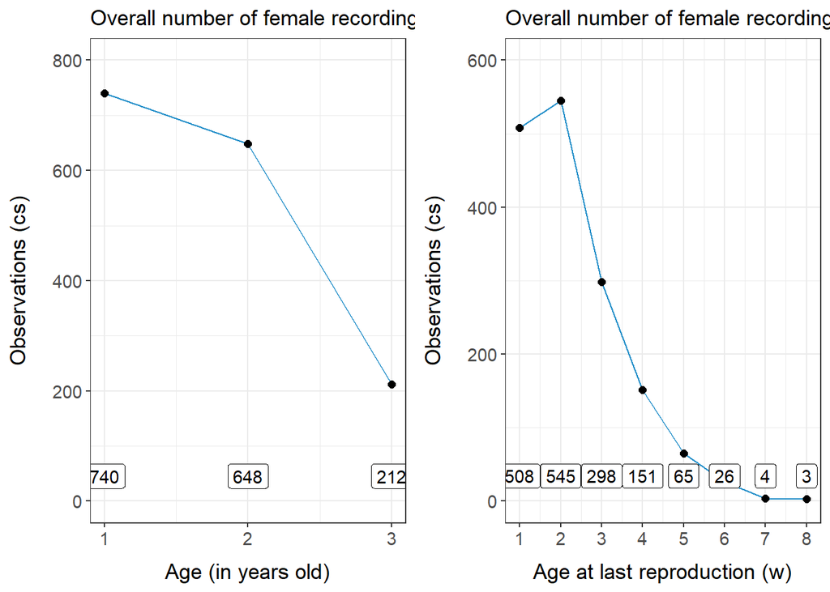

```r
csplot1 <- ggplot(cs_df, aes(x=yo)) +
  geom_freqpoly(colour="#248fc9", binwidth=1, linejoin = "round") +
  geom_point(stat="bin", aes(y=after_stat(count)), binwidth=1, colour="black", size = 2) +
  geom_label(stat="count", label = cs_age$n, vjust=-0.5, data = cs_age) +
  theme_bw() +
  scale_x_continuous(breaks=seq(1,3,1), limits=c(1,3)) +
  scale_y_continuous(limits=c(0,800)) +
  labs(x = "Age (in years old)", y = "Observations (cs)", title = "Overall number of female recordings per age (yo) group") +
  theme( axis.title = element_text(size = 13),
         axis.text = element_text(size = 11),
         axis.title.x = element_text(margin = unit(c(3, 0, 0, 0), "mm")),
         axis.title.y = element_text(margin = unit(c(0, 5, 0, 0), "mm")))

csplot2 <- ggplot(cs_df, aes(x=w)) +
  geom_freqpoly(colour="#248fc9", binwidth=1, linejoin = "round") +
  geom_point(stat="bin", aes(y=after_stat(count)), binwidth=1, colour="black", size = 2) +
  geom_label(stat="count", label = cs_w$n, vjust=-0.5, data = cs_w) +
  theme_bw() +
  scale_x_continuous(breaks=seq(1,8,1), limits=c(1,8)) +
  scale_y_continuous(limits=c(0,600)) +
  labs(x = "Age at last reproduction (w)", y = "Observations (cs)", title = "Overall number of female recordings per age-at-last-reproduction (w) group") +
  theme( axis.title = element_text(size = 13),
         axis.text = element_text(size = 11),
         axis.title.x = element_text(margin = unit(c(3, 0, 0, 0), "mm")),
         axis.title.y = element_text(margin = unit(c(0, 5, 0, 0), "mm")))

grid.arrange(csplot1, csplot2, ncol=2, nrow = 1)
```

```r
## For number of fledgelings

suc_age <- suc_df %>% dplyr::count(yo)

suc_w <- suc_df %>% dplyr::count(w)

suc_age  # number of observations per age group
```

```
##   yo   n
## 1  1 656
## 2  2 572
## 3  3 185
```

```r
suc_w  # number of observations per age-at-last-reproduction group
```

```
##   w   n
## 1 1 451
## 2 2 483
## 3 3 268
## 4 4 134
## 5 5  49
## 6 6  23
## 7 7   4
## 8 8   1
```

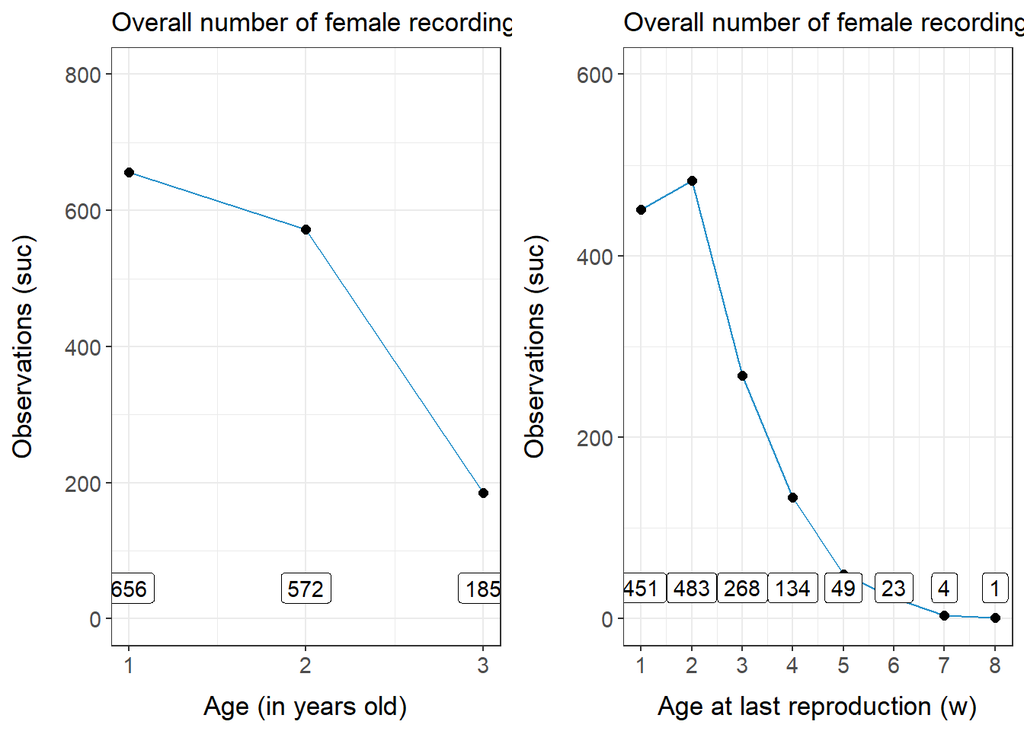

```r
sucplot1 <- ggplot(suc_df, aes(x=yo)) +
  geom_freqpoly(colour="#248fc9", binwidth=1, linejoin = "round") +
  geom_point(stat="bin", aes(y=after_stat(count)), binwidth=1, colour="black", size = 2) +
  geom_label(stat="count", label = suc_age$n, vjust=-0.5, data = suc_age) +
  theme_bw() +
  scale_x_continuous(breaks=seq(1,3,1), limits=c(1,3)) +
  scale_y_continuous(limits=c(0,800)) +
  labs(x = "Age (in years old)", y = "Observations (suc)", title = "Overall number of female recordings per age (yo) group") +
  theme( axis.title = element_text(size = 13),
         axis.text = element_text(size = 11),
         axis.title.x = element_text(margin = unit(c(3, 0, 0, 0), "mm")),
         axis.title.y = element_text(margin = unit(c(0, 5, 0, 0), "mm")))

sucplot2 <- ggplot(suc_df, aes(x=w)) +
  geom_freqpoly(colour="#248fc9", binwidth=1, linejoin = "round") +
  geom_point(stat="bin", aes(y=after_stat(count)), binwidth=1, colour="black", size = 2) +
  geom_label(stat="count", label = suc_w$n, vjust=-0.5, data = suc_w) +
  theme_bw() +
  scale_x_continuous(breaks=seq(1,8,1), limits=c(1,8)) +
  scale_y_continuous(limits=c(0,600)) +
  labs(x = "Age at last reproduction (w)", y = "Observations (suc)", title = "Overall number of female recordings per age-at-last-reproduction (w) group") +
  theme( axis.title = element_text(size = 13),
         axis.text = element_text(size = 11),
         axis.title.x = element_text(margin = unit(c(3, 0, 0, 0), "mm")),
         axis.title.y = element_text(margin = unit(c(0, 5, 0, 0), "mm")))

grid.arrange(sucplot1, sucplot2, ncol=2, nrow = 1)
```

### 4. Exploring breeding traits separately

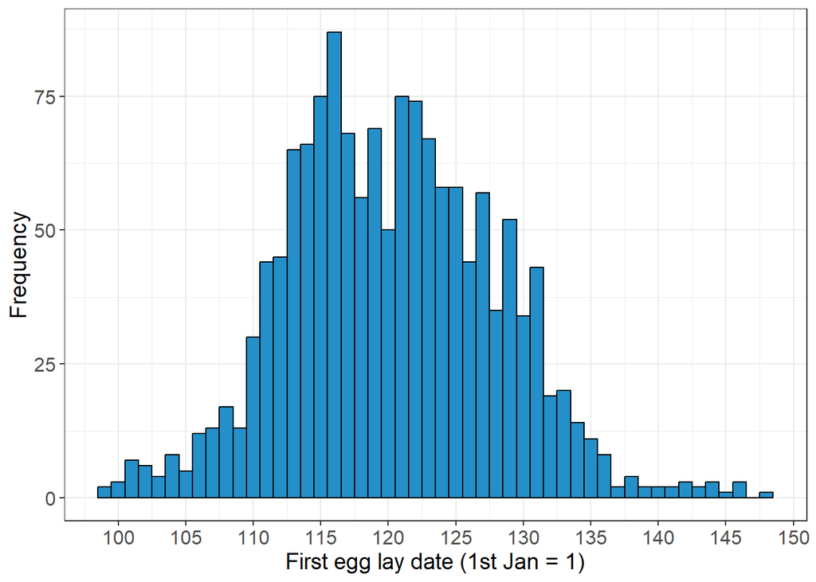

```r
level_order <- c("EDI", "RSY", "FOF", "BAD", "LVN", "DOW", "GLF", "SER", "MCH", "PTH", "STY", "BIR", "DUN", "BLG", "PIT", "KCK", "KCZ", "BLA", "CAL", "DNM", "DNC", "DNS", "DLW", "CRU", "NEW", "HWP", "INS", "FSH", "RTH", "AVI", "AVN", "CAR", "SLS", "TOM", "DAV", "ART", "MUN", "FOU", "ALN", "DEL", "TAI", "SPD", "OSP", "DOR")
## First egg lay date ##

# Overall first egg lay date
ggplot(blutidf, aes(fed)) +
  geom_histogram(colour = "black", fill = "#248fc9", binwidth=1) +
  labs(x = "First egg lay date (1st Jan = 1)", y = "Frequency") +
  theme_bw() +
  scale_x_continuous(breaks=seq(90,200,5)) +
  theme(axis.title = element_text(size = 14), axis.text = element_text(size = 12))
```

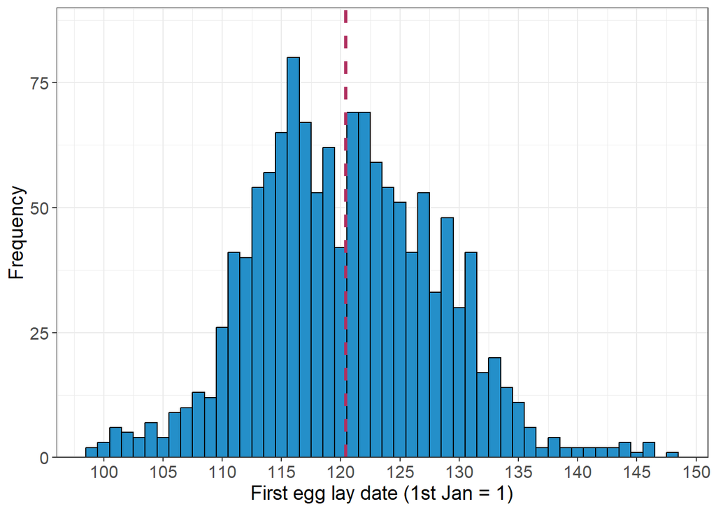

```r
# Overall first egg lay date (up until 3 y.o.)
ggplot(fed_df, aes(fed)) +
  geom_histogram(colour = "black", fill = "#248fc9", binwidth=1) +
  geom_vline(xintercept = mean(fed_df$fed), colour = "maroon", linewidth = 1.2, linetype = 2) +
  labs(x = "First egg lay date (1st Jan = 1)", y = "Frequency") +
  theme_bw() +
  scale_x_continuous(breaks=seq(90,200,5)) +
  scale_y_continuous(expand = c(0, 0), limits=c(0,90)) +
  theme(axis.title = element_text(size = 14), axis.text = element_text(size = 12))  # at first glance, although it looks a bit shifted, first egg lay date appears to be more or less Normally distributed
```

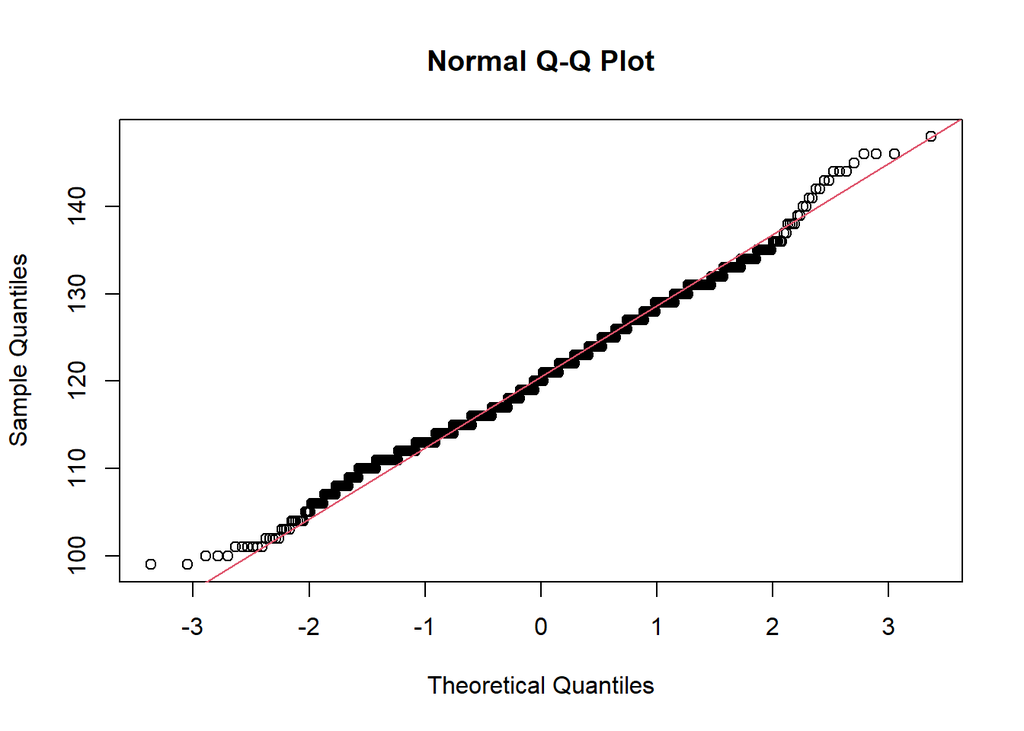

```r
qqnorm(blutidf_3yo$fed); qqline(blutidf_3yo$fed, col = 2)  # the observations mostly align with the diagonal that crosses through the first and third quantiles of the theoretical Normal distribution, except for the tails of the data distribution.
```